# AMMS Population Structure from Allele Frequencies Practical

Izzy Routledge, Bob Verity

July 30, 2022

# Dependencies for Practical

Please copy and paste the below code chunk in it’s entirety to your console to download R package libraries needed for this practical. If you are having trouble installing any of the R packages, please ask an instructor for a pre-loaded flash drive.

```r
deps <- c("tidyverse", "genescaper", "MIPanalyzer","rmaverick")
deps <- !sapply(deps, function(x){x %in% installed.packages()[,1]})
if (any(deps)) {
  if (deps["tidyverse"]) {
    install.packages("tidyverse")
  }
  if (deps["genescaper"]) {
    devtools::install_github("mrc-ide/genescaper", ref = "v0.1.0")
  }
  if (deps["MIPanalyzer"]) {
    devtools::install_github("mrc-ide/MIPanalyzer", ref = "v1.0.0")
  }
  if (deps["rmaverick"]) {
    devtools::install_github("bobverity/rmaverick", ref = "v1.1.0")
  }
}
```

Now load all of those libraries into this session using the code chunk below. Please copy and paste it in its entirety.

```r
library(tidyverse)
library(genescaper)
library(MIPanalyzer)
library(rmaverick)
```

Finally, source the additional functions that are needed for this practical by copy-pasting this function:

```r
source("source_functions/pop_structure_utils.R")
```

# Intro to population structure and allele frequency metrics

One of the most fundamental observations that we can make from genetic data is how the frequencies of different alleles vary over time and over space.

For loci where mutations confer drug resistance, allele frequencies tell us something with direct clinical implications - if an allele is at high frequencies then we might consider switching first-line drugs.

However, even for loci that have no direct impact on phenotype, and therefore are selectively neutral, allele frequencies can give us important information about what is going on in the parasite population.

These loci will be influenced by factors such as prevalence, human and mosquito population size, and migration rates between different sub-populations. If we can correctly interpret these signals then we can use neutral allele frequencies to tell us things about population structure and connectivity that can be relevant for control purposes.

**Definition:** An allele is the identity of a particular genetic locus or sequence that is inherited between parents and offspring.

**Definition:** A locus is a fixed position on a chromosome where a particular genetic marker is located.

**Definition:** A neutral allele is one which is not positively or negatively affecting an organism’s fitness and undergoing selection.

### Overview of Data

We will work with both simulated and real data in this practical. The simulated data will allow us to explore how allele frequencies change over time as a function of different underlying parameters - something that we can almost never do from messy real-world data. This will allow us to build up an intuition about what we would expect to see in real data. In the second half of the practical, we will use real-world datasetes including a large molecular inversion probe (MIP) dataset taken from DRC and surrounding countries, previously analysed by [Verity et al. 2020](https://pubmed.ncbi.nlm.nih.gov/32355199/). We will use this to explore population structure in various ways.

### Practical Goals

By the end of this practical, you should be able to:

- Describe how population size, mutation and migration rates affect the patterns that we expect to see in neutral allele frequency data
- Estimate metrics such as $F_{ST}$ and explain what they can tell us about population differentiation
- Use ordination techniques like PCA to explore patterns of population structure
- Use model-based techniques like *rmaverick* to detect population structure in a probability-driven way
- Appreciate how allele frequency methods can identify connectivity over large spatial scales and long temporal scales
- Explain how allele frequencies can give useful information, and also describe their limitations for malaria control purposes

# Population genetics through simulation

First we will simulate a population and different frequencies of alleles. To do this we will use an R function called sim_freqs to generate allele frequencies.

## Focusing on a single subpopulation

Let’s consider a single subpopulation (e.g. village) where there is no barrier to gene flow, also known as a “deme”.

### Allele frequency changes in a single deme

First we will simulate the allele frequencies of a population of 1000 individuals infected with malaria. Try running this function lots of times. What do you notice about the allele frequency over time?

```r
sim1 <- sim_freqs(N = 1000, mut_rate = 0)
```

```
## simulation completed in 0 seconds
```

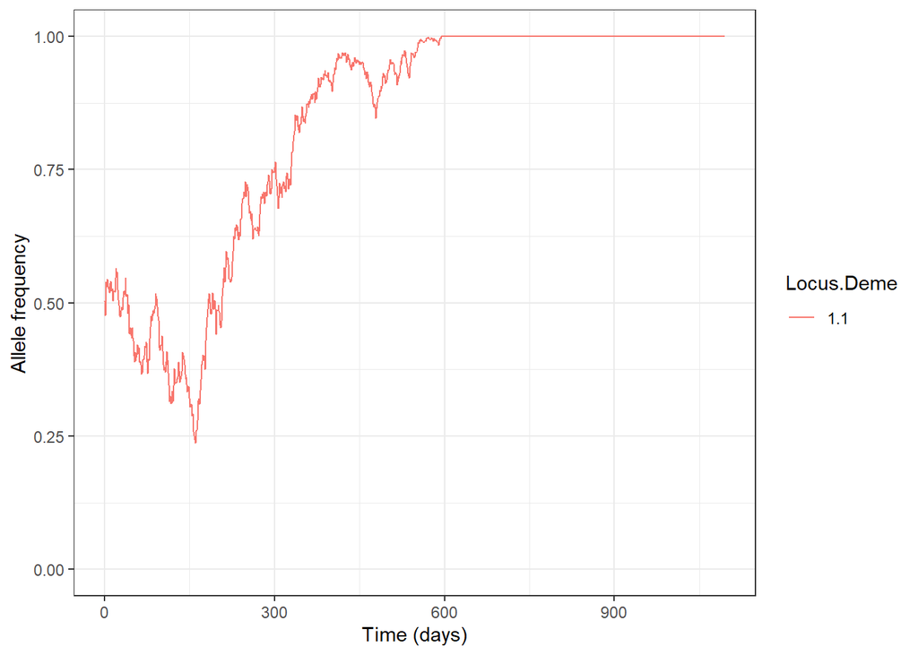

Now repeat with a smaller population size (which represents the number of *infected* hosts in our case). What do you notice about the strength of drift? What happens once an allele reaches a frequency of 0 or 1? Why is this?

**Definition:** Drift is the variation in the frequency of alleles in a small population due to the random loss of alleles across generations.

```r
sim_freqs(N = 100, mut_rate = 0)
```

```
## simulation completed in 0 seconds
```

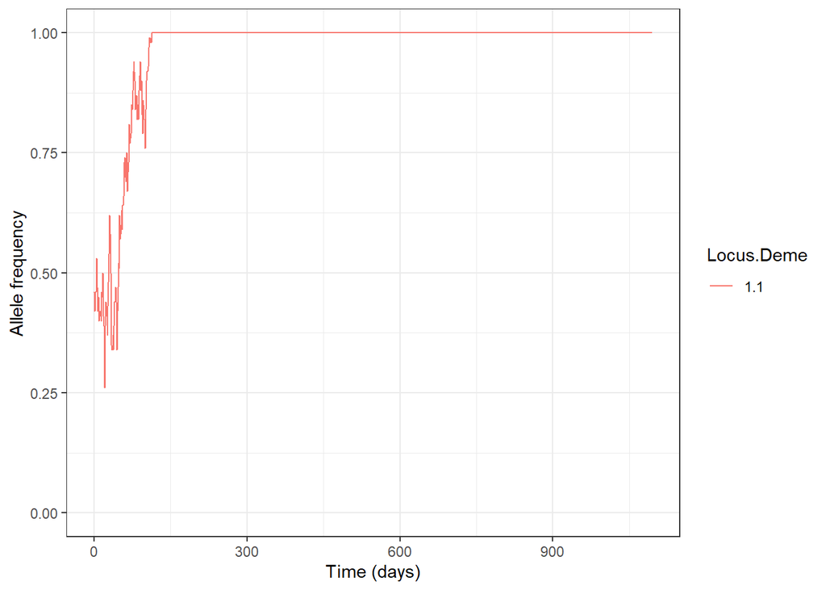

Now repeat the simulation, this time running for 10 years and with some mutation. Do frequencies still always end up fixed/lost?

```r
sim_freqs(N = 1000, t_out = seq(0, 365 * 10), mut_rate = 1e-4)
```

```
## simulation completed in 0.0159977 seconds
```

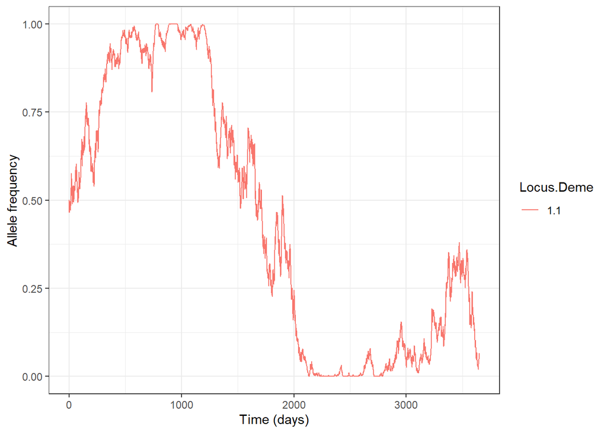

### The allele frequency spectrum

We will now simulate a large number of loci, but output at just a single timepoint.

```r
# simulate allele frequencies and look at the data
sim1 <- sim_freqs(N = 1000, t_out = 365 * 5, mut_rate = 1e-6, loci = 1e3, plot_on = FALSE)
```

```
## simulation completed in 0.492535 seconds
```

```r
head(sim1$data)
```

```
##   time deme locus  freq
## 1 1825    1     1 1.000
## 2 1825    1     2 0.962
## 3 1825    1     3 1.000
## 4 1825    1     4 0.202
## 5 1825    1     5 0.000
## 6 1825    1     6 0.494
```

We can plot this allele frequency spectrum

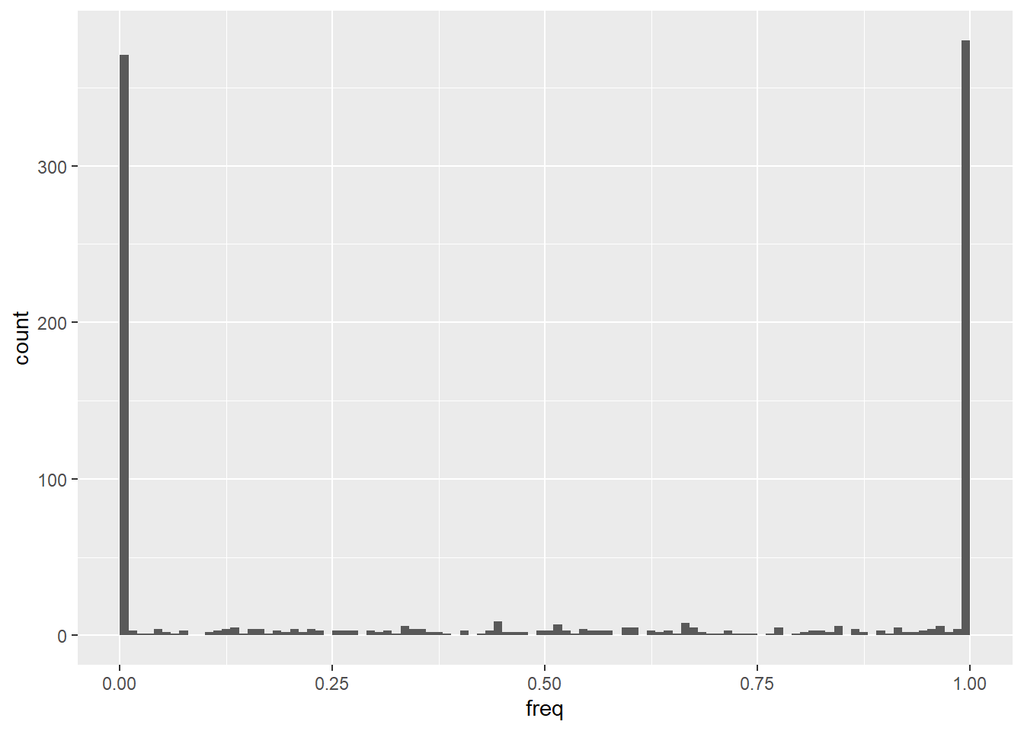

```r
# simulate allele frequencies and look at the data
ggplot(sim1$data) +
  geom_histogram(aes(x = freq), breaks = seq(0, 1, 0.01))
```

What happens if you increase the mutation rate? What happens if you increase the population size?

### The buildup of homozygosity

Run the code below multiple times to repeat the simulation of drift, but now also plotting homozygosity. What do you notice about how homozygosity changes over time? (It always increases to 1).

```
## simulation completed in 0.0085314 seconds
```

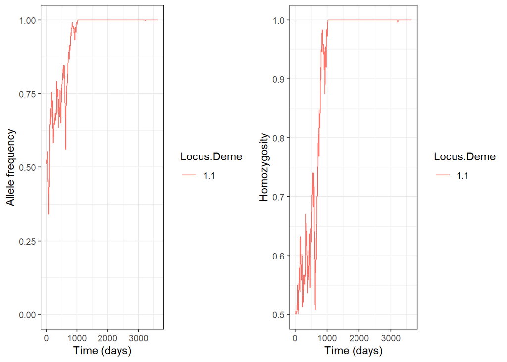

```r
sim_freqs(N = 1000, t_out = seq(0, 365 * 10, 7), plot_homo = TRUE)
```

What happens when you add in some mutation? Try mutation rates of 1e-3 and 1e-4. What happs to the equilibrium level of homozygosity?

```
## simulation completed in 0.0079988 seconds
```

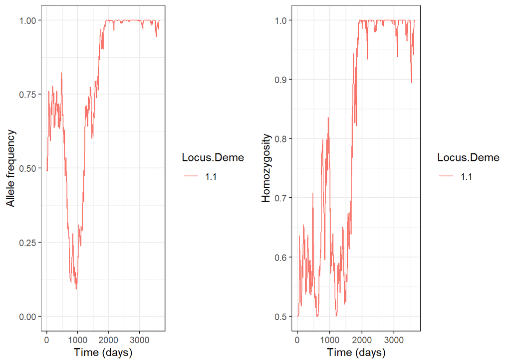

```r
sim_freqs(N = 1000, t_out = seq(0, 365 * 10, 7), mut_rate = 1e-4, plot_homo = TRUE)
```

We can add in a line showing the theoretical expectation.

```
## simulation completed in 0.0019937 seconds
```

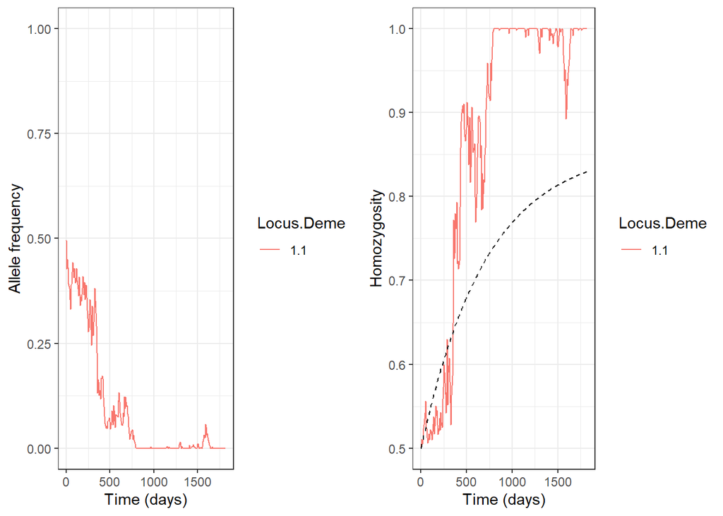

```r
sim_freqs(N = 1000, t_out = seq(0, 365 * 5, 7), mut_rate = 1e-4, plot_homo = TRUE, plot_expected_homo = TRUE)
```

## Multiple subpopulations

Now we will consider an example with multiple subpopulations (demes).

### Perfectly isolated subpopulations

Try running a simulation with 10 independent demes.This could represent ten villages where there is no movement of people between those villages. Notice that allele frequencies tend to diverge.

```r
sim1 <- sim_freqs(N = 1000, demes = 10, mig_rate = 0, mut_rate = 1e-4)
```

```
## simulation completed in 0.0136899 seconds
```

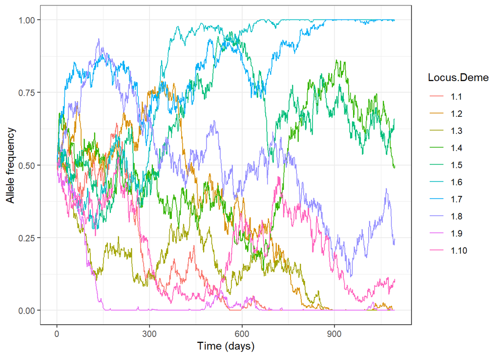

#### Calculating $F_{ST}$ to measure population differentiation

Next we will explore a metric used to measure population differentiation.

**Definition: Fixation index, or $F_{ST}$ and Jost’s D are both measures of genetic differentiation between different subpopulations.**

When $F_{ST}$ is close to **1** it means that individuals in a population tend to carry a *small number of alleles*. Individuals are “differentiated” in the sense that alleles are not freely mixing between people.

High values of $F_{ST}$ and Jost’s D both suggest a greater genetic differentiation between the subpopulations being measured. However both metrics have different approaches to measure genetic differentiation.

We can calculate a simple version of $F_{ST}$ manually

```r
sim_fst <- sim1$data %>%
  select(-locus) %>%
  group_by(time) %>%
  summarise(p_mean = mean(freq),
            p_var = var(freq),
            Fst = p_var / (p_mean * (1 - p_mean)))
```

Now lets plot $F_{ST}$ over time. What do you notice about differentiation?

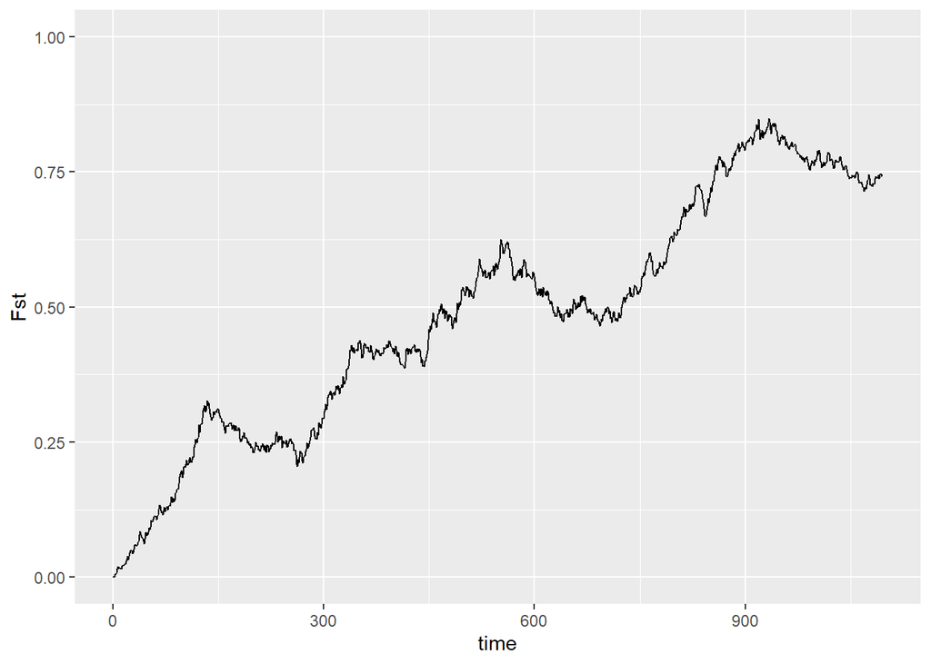

```r
ggplot(sim_fst) +
  geom_line(aes(x = time, y = Fst)) +
  expand_limits(y = c(0, 1))
```

What happens if you repeat the process above with a higher mutation rate?

```r
sim1 <- sim_freqs(N = 100, demes = 10, mig_rate = 0, mut_rate = 1e-3,
                  t_out = seq(0, 365*10, 7), plot_on = FALSE)
```

```
## simulation completed in 0.0080007 seconds
```

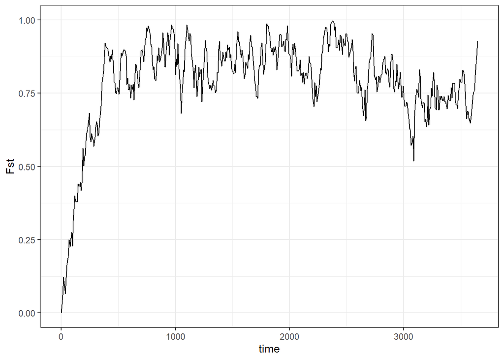

```r
sim1$data %>%
  select(-locus) %>%
  group_by(time) %>%
  summarise(p_mean = mean(freq),
            p_var = popvar(freq),
            Fst = p_var / (p_mean * (1 - p_mean))) %>%
  ggplot() + theme_bw() +
  geom_line(aes(x = time, y = Fst)) +
  expand_limits(y = c(0, 1))
```

The equilibrium level of $F_{ST}$is known to be 1/(1 + 2*N*mu) in this case. How does this level compare with what you saw in the plot?

```r
# e.g. use
#geom_hline(yintercept = 1 / (1 + 2*1e2*1e-3), linetype = "dashed")
```

The fact that $F_{ST}$ depends on the mutation rate can lead to problems. If one marker has a high mutation rate (e.g. microsatellites) then we would expect to see low values of $F_{ST}$, even if the populations have been evolving separately for a long time, and in this sense are well differentiated.

Jost’s D is an alternative way of looking at differentiation.

When Jost’s D is close to **1** it means that alleles tend to be present in *a small number of individuals*. Individuals are “differentiated” in the sense that they contain different genetic material.

```r
sim1 <- sim_freqs(N = 100, demes = 10, mig_rate = 0, mut_rate = 1e-3,
                  t_out = seq(0, 365*10, 7), plot_on = FALSE)
```

```
## simulation completed in 0.0134372 seconds
```

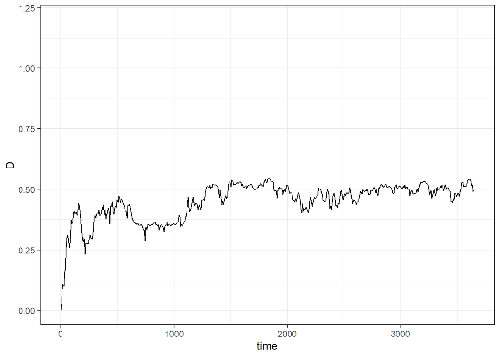

```r
sim1$data %>%
  select(-locus) %>%
  group_by(time) %>%
  summarise(Js = mean(freq^2 + (1 - freq)^2),
            Jt = mean(freq)^2 + mean(1 - freq)^2,
            D = (Js - Jt) / Js * max(deme) / (max(deme) - 1)) %>%
  ggplot() + theme_bw() +
  geom_line(aes(x = time, y = D)) +
  expand_limits(y = c(0, 1.2))
```

Jost’s D does not suffer from the same problem as $F_{ST}$, but it suffers from a different problem - it assumes infinite alleles mutation. When we have a biallelic SNP, Jost’s D will tend to reach values of around 0.5 at equilibrium. (This is actually a bit of a subtle point - maybe easier to understand if I generalise the above to allow more than two alleles?)

In conclusion, both $F_{ST}$ and D have their limitations. $F_{ST}$ is good when mutation rates are low, for example biallelic SNPs. Jost’s D is good for highly diverse and fast-mutating sites, such as microsats.

### Connected subpopulations

What happens when we connect our demes up by migration? Try experimenting with larger and smaller migration rates in the following. What do you notice about the allele frequencies? (lines tend to be less bumpy and move together when migration is high)

```r
sim_freqs(N = 1000, demes = 5, mig_rate = 0.01)
```

```
## simulation completed in 0.0170615 seconds
```

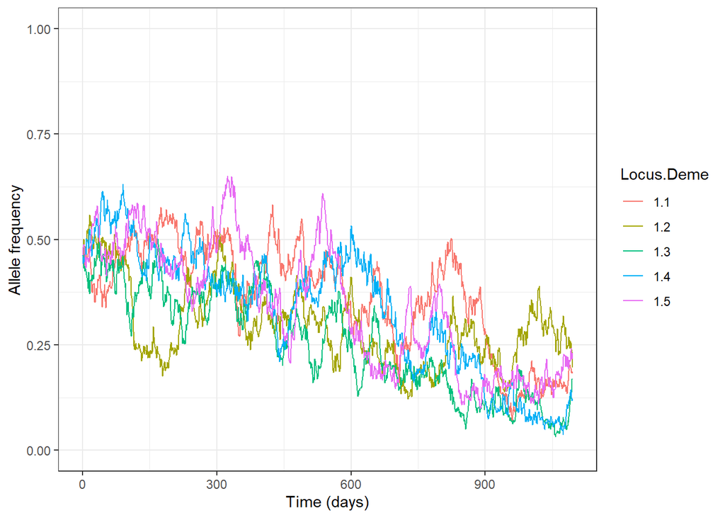

Lets look at what happens to $F_{ST}$ when we include migration. What happens when you increase/decrease the migration rate?

```r
sim1 <- sim_freqs(N = 1000, demes = 10, t_out = seq(0, 365*20, 7), mig_rate = 1e-3,
                  mut_rate = 1e-6, plot_on = FALSE)
```

```
## simulation completed in 0.0984714 seconds
```

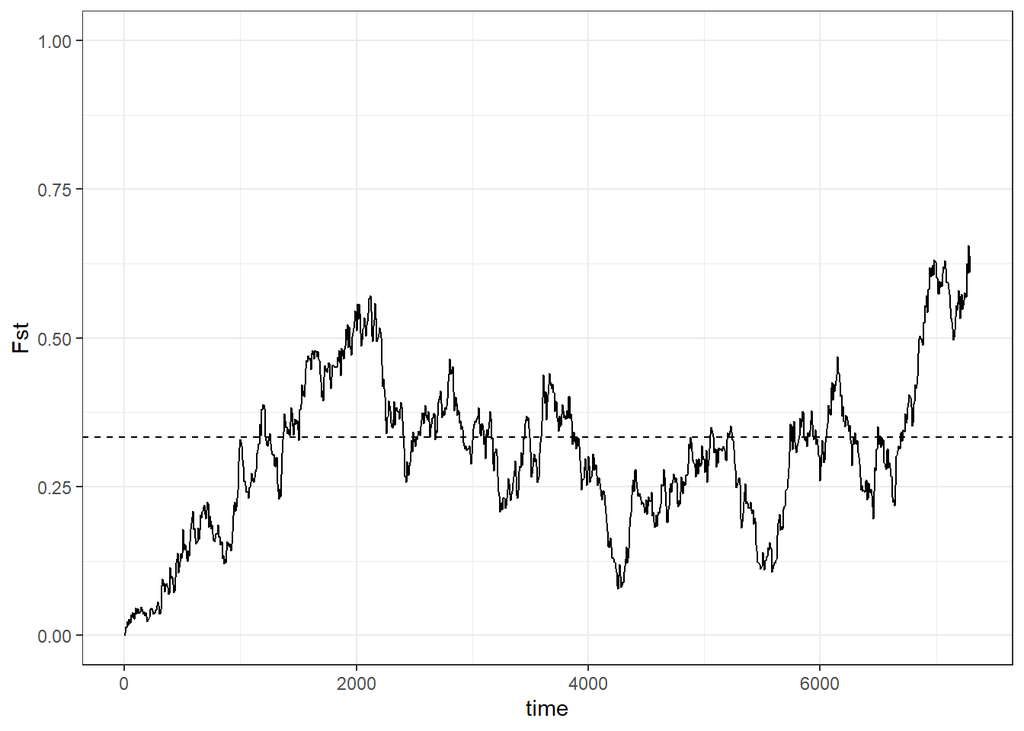

```r
sim1$data %>%
  select(-locus) %>%
  group_by(time) %>%
  summarise(p_mean = mean(freq),
            p_var = popvar(freq),
            Fst = p_var / (p_mean * (1 - p_mean))) %>%
  ggplot() + theme_bw() +
  geom_line(aes(x = time, y = Fst)) +
  expand_limits(y = c(0, 1)) +
  geom_hline(yintercept = 1 / (1 + 2*1e3*(1e-3 + 1e-6)), linetype = "dashed")
```

Theory tells us that the equilibrium level of $F_{ST}$ in this situation is given by 1/(1 + 2*N*(m + mu)). Does this result hold up this your simulations? (yes, on average). Note that migration rates are usually much larger than mutation rates, meaning we can often simplify this to 1/(1 + 2*N*m).

Conclusion - at equilibrium, $F_{ST}$ reaches a level that is a balance between the strength of genetic drift (i.e. small population size) and migration. The higher the migration rate, the lower the value of $F_{ST}$. This means we can use $F_{ST}$ to tell us something about the connectivity of populations. Small pairwise $F_{ST}$ tends to indicate highly connected populations and vice versa.

Note, however, that these patterns take a very long time to build up. So we are not talking about the timescale of control programmes, but more of an evolutionary timescale.

# Analysis of DRC data

Now we will explore allele frequencies in a real dataset. First, we will load a dataset collected using Molecular Inversion Probes (MIPs) from the Democratic Republic of the Congo. MIPs are a method of high throughput sequencing

This data is a slightly simplified version of that used in this paper : [Verity et al. 2020](https://pubmed.ncbi.nlm.nih.gov/32355199/).

Have a look at the data using the *MIPanalyzer* package.

```r
# load data
MIP_data <- readRDS("data/DRC_MIPs_biallelic_processed.rds")

# have a look at the data
MIP_data

head(MIP_data$samples)
```

```
##                       ID Country Admin1_name Year Latitude Longitude Cluster
## 07GHR5002-AG-1 07GHR5002   Ghana        <NA> 2013 6.385908 -0.376496       1
## 07GHR5006-AG-1 07GHR5006   Ghana        <NA> 2013 6.385908 -0.376496       1
## 07GHR5018-AG-1 07GHR5018   Ghana        <NA> 2013 6.385908 -0.376496       1
## 07GHR5025-AG-1 07GHR5025   Ghana        <NA> 2013 6.385908 -0.376496       1
## 07GHR5028-AG-1 07GHR5028   Ghana        <NA> 2013 6.385908 -0.376496       1
## 07GHR5029-AG-1 07GHR5029   Ghana        <NA> 2013 6.385908 -0.376496       1
```

```r
head(MIP_data$loci)
```

```
##    CHROM    POS REF ALT     NEUTRAL            GEO
## 9      1 100608   A   G     Neutral Non-geographic
## 19     1 138823   C   T     Neutral Non-geographic
## 31     1 139191   C   T Non-neutral     Geographic
## 35     1 140820   A   C Non-neutral     Geographic
## 36     1 155939   G   A     Neutral Non-geographic
## 63     1 182927   T   C     Neutral Non-geographic
```

let’s create a copy of the dataset that does not include any DRC samples:

```r
# filter samples
MIP_data_noDRC <- MIPanalyzer::filter_samples(MIP_data, MIP_data$samples$Country != "DRC")

MIP_data_noDRC
```

Principal Components Analysis or PCA can be used to reduce the number of dimensions or variables in a dataset, and can be used to more easily summarize data and in this case visualise genetic differentiation.

Now lets do PCA on the within-sample allele frequencies.

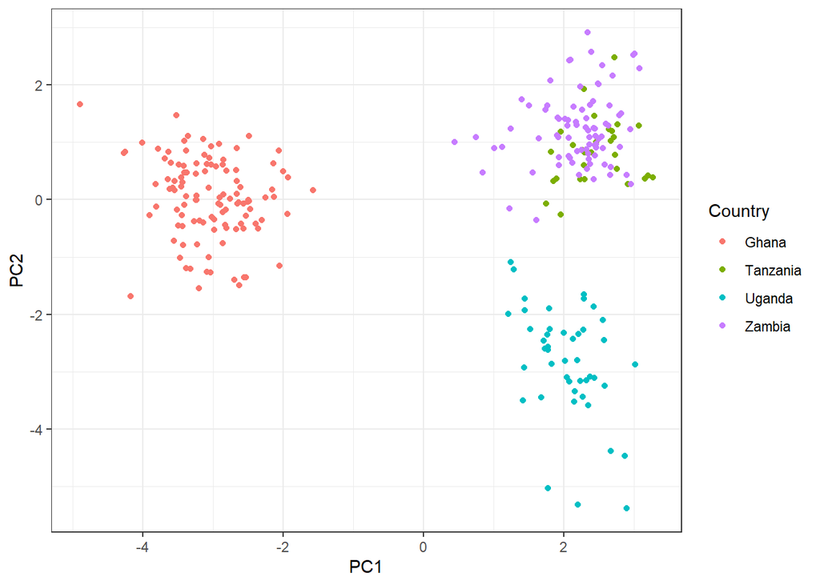

```r
wsaf_impute <- MIPanalyzer::get_wsaf(MIP_data_noDRC, impute = TRUE, FUN = mean)
pca <- MIPanalyzer::pca_wsaf(wsaf_impute)

plot_df <- data.frame(PC1 = pca$x[,1],
                      PC2 = pca$x[,2],
                      Country = MIP_data_noDRC$samples$Country)

ggplot(plot_df) + theme_bw() +
  geom_point(aes(x = PC1, y = PC2, color = Country))
```

We see well-separated clusters, which makes sense geographically. Now let’s repeat the process using all samples including those from DRC.

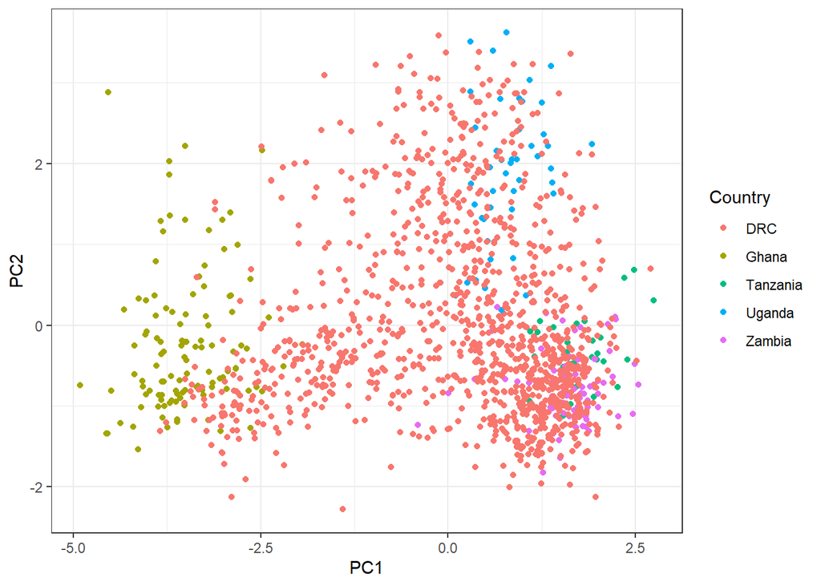

```r
wsaf_impute <- MIPanalyzer::get_wsaf(MIP_data, impute = TRUE, FUN = mean)
pca <- MIPanalyzer::pca_wsaf(wsaf_impute)

plot_df <- data.frame(PC1 = pca$x[,1],
                      PC2 = pca$x[,2],
                      Country = MIP_data$samples$Country)

ggplot(plot_df) + theme_bw() +
  geom_point(aes(x = PC1, y = PC2, color = Country))
```

The DRC points connect the other points. This suggests that there is more of a spatial continuum of allele frequencies.

We can plot the contributions that each locus makes to this PCA. Starting with PC1, what do you notice about the balance of geographically informative vs. non-informative SNPs? (the pattern is mostly driven by geographically informative SNPs). What does this suggest? (the primary factor driving this PCA is spatial location)

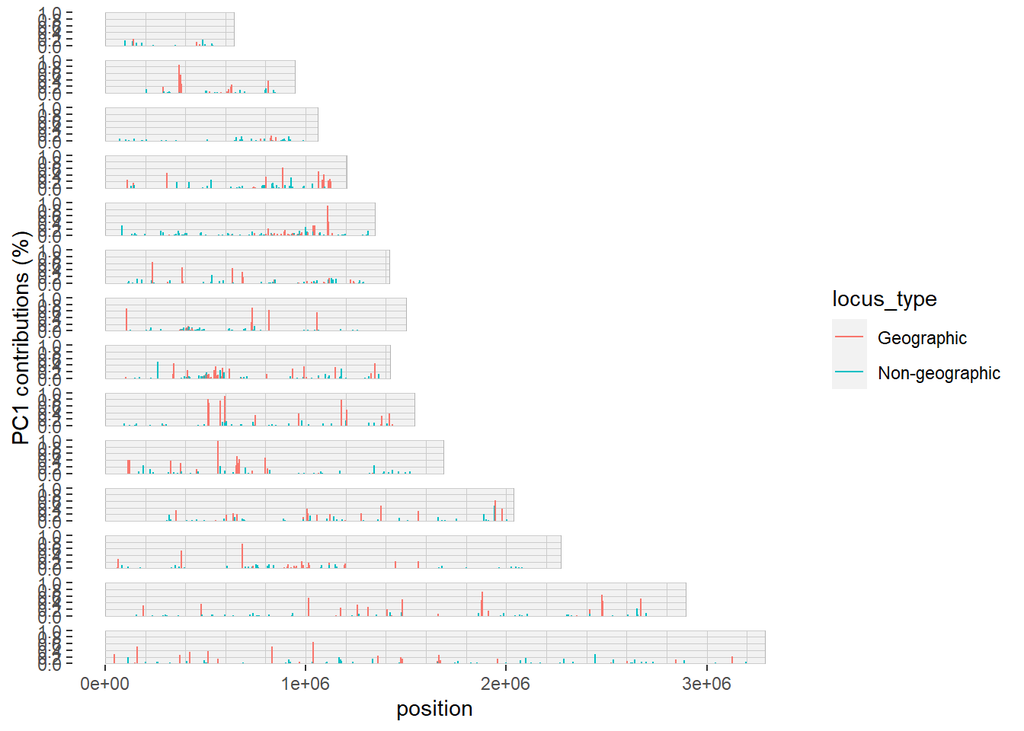

```r
# plot component 1
MIPanalyzer::plot_pca_contribution(pca, component = 1, chrom = MIP_data$loci$CHROM, pos = MIP_data$loci$POS,
                                   locus_type = MIP_data$loci$GEO)
```

Now repeat the process with PC2. What do you notice about where these loci are on the genome? (they are all in one or two places). What genes are at these positions? (pfcrt on chrom7. Small peak at dhps on chromosome 8)

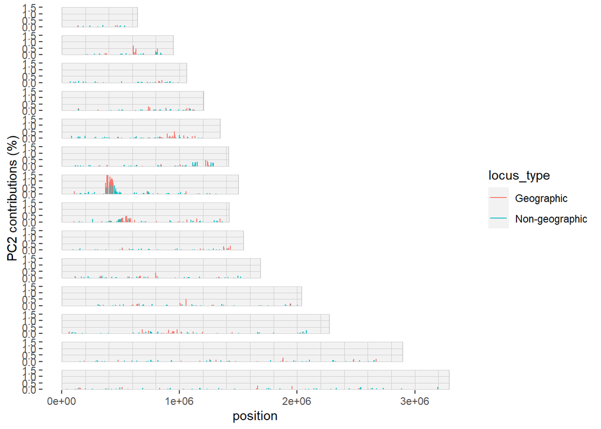

```r
# plot component 2
MIPanalyzer::plot_pca_contribution(pca, component = 2, chrom = MIP_data$loci$CHROM, pos = MIP_data$loci$POS,
                                   locus_type = MIP_data$loci$GEO)
```

# Inferring population structure using *rmaverick*

*rmaverick* is an R package which we will use to further investigate population structure.

First we will load genetic barcode data from [Bei et al., 2018](https://pubmed.ncbi.nlm.nih.gov/29325146/) . This study contains samples taken at two separate time points over ten years apart in two locations in Senegal. These data have already been filtered to remove the two Thies samples, and to order in terms of date (2001-2002 vs. 2014) and location (Dielmo and Ndiop).

Now let’s look at a snapshot of the data, which includes measures of transmission intensity in the two timepoints and regions. We will look at: - Entomological Innoculation Rate (EIR) - The barcodes - The SNP locations

```r
load("data/Bei_2018_processed.RData")

head(Bei_2018_processed$EIR)
```

```
##   Time range Location   EIR
## 1       2001   Dielmo 353.8
## 2       2002   Dielmo 409.9
## 3       2001    Ndiop 171.9
## 4       2002    Ndiop  16.9
## 5       2014   Dielmo  26.3
## 6       2014    Ndiop <0.05
```

```r
head(Bei_2018_processed$barcodes)
```

```
##   Sample Code       Date Sex  Age Parasite Density Location M/P genomic A1 B1
## 1        IP09 2001-01-02   F  3.4             9150   Dielmo           M  C  A
## 2        IP07 2001-01-03   F  2.6            20800   Dielmo           P  T  A
## 3        IP03 2001-02-05   M 10.5             6450   Dielmo           P  N  A
## 4        IP05 2001-02-05   F  3.8            22200   Dielmo           P  C  A
## 5        IP01 2001-02-06   M  2.3            10550   Dielmo           P  N  N
## 6        IP08 2002-01-07   F  3.7            29450   Dielmo           M  T  A
##   A2 B2 A3 B3 A4 B4 A5 B5 A6 B6 A7 B7 A8 B8 A9 B9 A10 B10 A11 B11 A12 B12
## 1  C  C  G  C  A  G  T  T  T  A  T  C  A  A  C  T   C   G   A   T   T   G
## 2  C  T  C  C  G  G  T  N  T  A  C  C  C  C  C  A   C   A   C   N   T   G
## 3  N  T  C  N  N  G  N  T  T  A  C  N  C  N  N  N   A   N   A   T   T   G
## 4  T  C  G  C  A  G  T  C  T  N  T  A  C  C  C  N   A   A   A   N   T   G
## 5  C  N  G  C  N  G  N  C  T  A  N  N  C  C  N  N   A   N   A   N   T   G
## 6  C  C  G  C  G  A  A  T  T  A  T  A  C  C  C  T   A   G   A   C   T   G
```

```r
head(Bei_2018_processed$SNP_locations)
```

```
##   SNP code    SNP location
## 1       A1 Pf_01_000130573
## 2       B1 Pf_01_000539044
## 3       A2 Pf_02_000842803
## 4       B2 Pf_04_000282592
## 5       A3 Pf_05_000931601
## 6       B3 Pf_06_000145472
```

Some data processing

```r
# filter out polygenomics
mav_data <- Bei_2018_processed$barcodes %>%
  filter(`M/P genomic` == "M")

# convert genotype calls to numeric
for (i in 8:31) {
  mav_data[,i] <- match(mav_data[,i], c("A", "C", "T", "G"))
}

head(mav_data)
```

```
##   Sample Code       Date Sex  Age Parasite Density Location M/P genomic A1 B1
## 1        IP09 2001-01-02   F  3.4             9150   Dielmo           M  2  1
## 2        IP08 2002-01-07   F  3.7            29450   Dielmo           M  3  1
## 3        IP06 2002-01-14   M  1.1            10000   Dielmo           M  3  1
## 4        IP04 2002-02-03   F 11.6            19750   Dielmo           M  3  1
## 5        IP17 2001-01-02   M  5.6            13600    Ndiop           M  3  1
## 6        IP11 2001-05-02   M  0.7             2150    Ndiop           M  3  1
##   A2 B2 A3 B3 A4 B4 A5 B5 A6 B6 A7 B7 A8 B8 A9 B9 A10 B10 A11 B11 A12 B12
## 1  2  2  4  2  1  4  3  3  3  1  3  2  1  1  2  3   2   4   1   3   3   4
## 2  2  2  4  2  4  1  1  3  3  1  3  1  2  2  2  3   1   4   1   2   3   4
## 3  3  2  4  2  4  4  3  3  3  1  3  2  1  2  2  1   1   4   1   2   3   4
## 4  3  3  4  2  4  4  3  2  3  1  2  2  1  2  3  1   1   4   1   2   3   4
## 5  3  3  2  2  1  4  3  3  3  1  2  2  1  1  2  3   1   4   1   3   3   4
## 6  2  3  2  4  4  4  3  2 NA  4  3  1  2  1  3  1   2   4   1   2   3   4
```

Next, load the data into *rmaverick*, and set up our first model. Then print the project to check everything looks as planned (25 samples, 24 loci etc.)

```r
myproj <- rmaverick::mavproject() %>%
  rmaverick::bind_data(df = mav_data, ID_col = 1, data_cols = 8:31, ploidy = 1) %>%
  rmaverick::new_set(name = "no admixture model", admix_on = FALSE)

myproj
```

```
## DATA:
##    individuals = 25
##    loci = 24
##    ploidy = 1
##    pops = 1
##    missing data = 2 of 600 gene copies (0%)
##
## PARAMETER SETS:
##  * SET1: no admixture model
##
## ACTIVE SET: SET1
##    model = no-admixture
##    lambda = 1
```

Markov Chain Monte Carlo (MCMC) approaches allow us to fit models by sampling from complex probability distributions. Here we will use MCMC to fit our model in rmaverick.

Let’s run an MCMC in rmaverick. Users should run this with pb_markdown = FALSE.

```r
myproj <- rmaverick::run_mcmc(myproj, K = 1:8, burnin = 1e3, samples = 1e3,
                              rungs = 10, GTI_pow = 1.5, pb_markdown =  TRUE)
```

[output not shown]

First we will carry out some MCMC diagnostic checks. Check that coupling acceptance rates are above 0. Do this for every value of K (the number of subpopulations) from 2 to the max value explored.

[Question for Bob - is rmaverick MCMCMC? Not sure how far to get into the diagnostics but I think more explanation required.]

**Definition: Coupling acceptance rates are the rates of proposals in the MCMC which are accepted .**

**Definition: The K value is the number of subpopulations in rmaverick.**

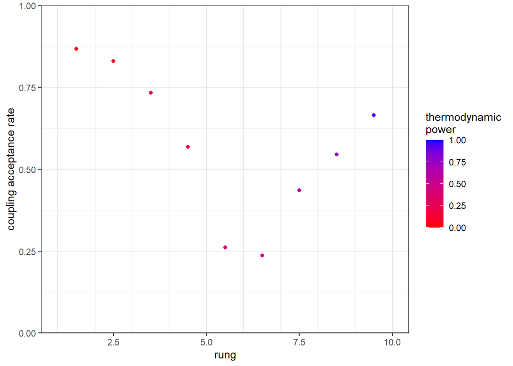

```r
rmaverick:::plot_mc_acceptance(myproj, K = 8)
```

Now check what the program thinks about the best value of K. In this case, values around 3-5 are reasonably likely

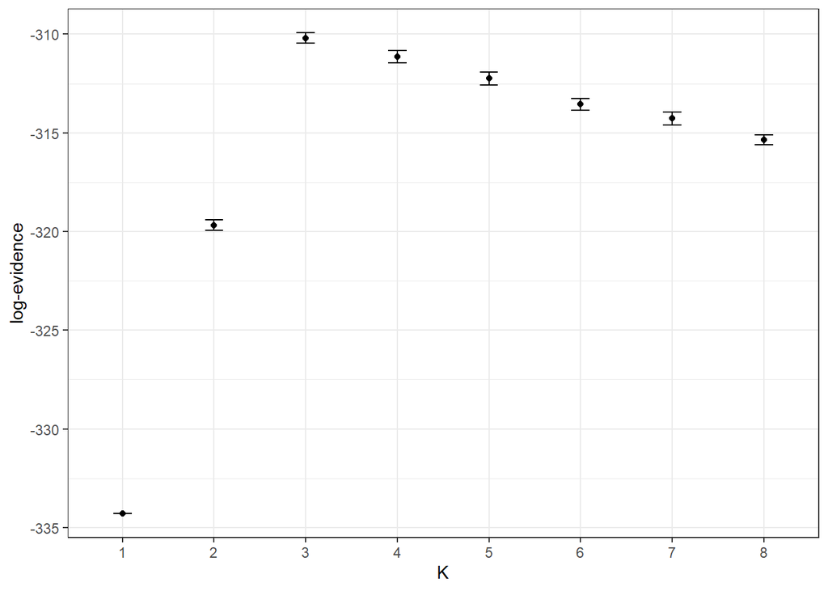

```r
rmaverick::plot_logevidence_K(myproj)
```

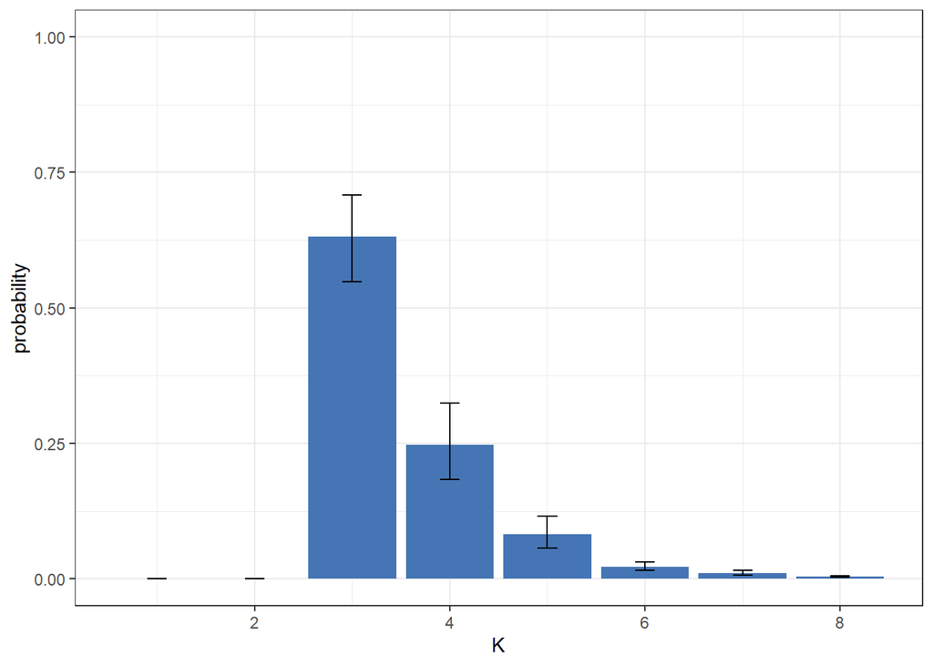

```r
rmaverick::plot_posterior_K(myproj)
```

Finally, produce a Structure plot. We will add vertical lines to break up into the following groups: 1. Dielmo 2001-2001 2. Ndiop 2001-2002 1. Dielmo 2014 2. Ndiop 2014

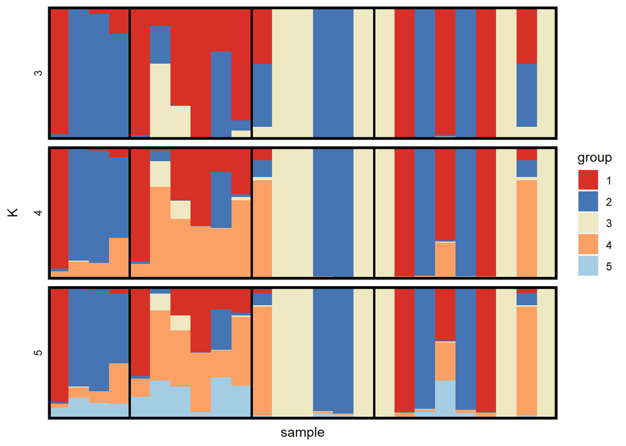

```r
rmaverick::plot_qmatrix(myproj, K = 3:5) +
  geom_vline(xintercept = c(4, 10, 16) + 0.5, size = 1)
```

Notice that the later samples are (mostly) clearly allocated to one or other population with high probability. These essentially represent clonal lineages. We can see that groups 2,3,4 are present in Dielmo in 2014, and in Ndiop we additionally have group 1.

Comparing this to the earlier time point, samples are far more ambigious in their allocation. They look a bit like some of these clonal lineages, but it’s not clear cut, probably because there is some additional variation. Interestingly, group 4 dominates in Ndiop in 2001-2002. This lineage is almost completely lost by the later sampling point.

Overall, we can see evidence of increasing population structure over time. Compare this with the EIR values - what do you notice? (lower transmission later in time, therefore increasing differentiation and population structure).